# Java

References to cite in Markdown document

2020-07-01

Abstract

References to cite in Markdown document

# Lab 5. Sorting Algorithms

## Insertion Sort :zap:

### Background

**Definition.** a Java sorting method where the sorted values locate to the low end of the array, and the unsorted values locate to the high end. There are

[figure not shown]

passes over the array, with a new unsorted value inserted each time

- expected running time is

[figure not shown]

  compares and data movements –most compares will lead to movement of a data value
- best case running time performance is

[figure not shown]

  comparisons –occurs for no movements of data within the array
- therefore, it’s best to implement insertion sort on data that is nearly ordered

#### Show how Insertion Sort acts on the following List:

```java
list X: 7 5 4 6 8 2
```

- Iterate through the array
- Shifting all of the elements to the right until we encounter the first element we don’t have to shift
- Place the new element into its proper place within the sorted subarray

[figure not shown]

### Java Methods

#### Method to Insertion Sort a generic type that extends the interface Relateable

1. create a LinkedList
2. initialize ICount
3. walk down ArrayList and insert each element into sorted LinkedList
4. repackage and return ArrayList
5. method to insert a new element myObj into a sorted LinkedList
   - use a loop to traverse LinkedList
   - begin with first element (smallest T) and find where myObj should go
6. debugging tool and method to dump out content in LinkedList

### Code Output

#### Execution Times

At the worst case scenario for the algorithm, the whole array is descending. This is because in each iteration, we’ll have to move the whole sorted list by 1, which is

[figure not shown]

. We have to do this for each element in every array, which means it’s going to be bounded by

[figure not shown]

.

## Bubble Sort :thought_balloon:

### Background

**Definition.** Bubble sort checks and rechecks the relation between each component of the list. The method sorts the

[figure not shown]

elements by linearly moving through the list

- where each pass completes

[figure not shown]

  comparisons and

[figure not shown]

  exchanges.
- After one pass, the largest integer-value should “bubble” up to the ArrayList’s high-indexed side –the operation repeats.
- After

[figure not shown]

  passes, the bubble sorting terminates.

### Java Methods

#### Bubble Sort Class

1. Method sorts the elements by linearly moving through the list
2. After a pass, the largest value “bubbles” up the ArrayList
3. Bubble sorting repeats for (n-1) passes

### Code Output

#### Execution Times

[figure not shown]

[figure not shown]

elements of an array is

[figure not shown]

; hence, the algorithm has a run time that grows quadratically as the input (data points) size grows.

## Merge Sort :collision:

### Background

**Definition.** MergeSort is a recursive sorting technique that recursively splits, sorts, and reconstructs the data. This method recursively

- divides the data into two unsorted lists,
- sorts the two lists,
- and then merges the two sorted lists.

### Java Methods

#### Merge Sort Algorithm

1. Break the whole array down into two subarrays
2. Sort the left half of the array (recursively)
3. Sort the right half of the array (recursively)
4. Merge the solutions

### Code Output

#### Execution Times

Each value

[figure not shown]

in the data set must be sorted into a temporary array, allotted once before every single merge; therefore, we have

[figure not shown]

[figure not shown]

In **big-O notation**, since there are

[figure not shown]

split levels, we have a time execution of

[figure not shown]

## Summary

### Sorting Techniques:

From the graph below, we can see that the number of steps to execute the Merge Sort method is significantly lower than the number of steps to execute the Bubble Sort method; hence, the Merge Sort is faster and more efficient than the Bubble Sort.

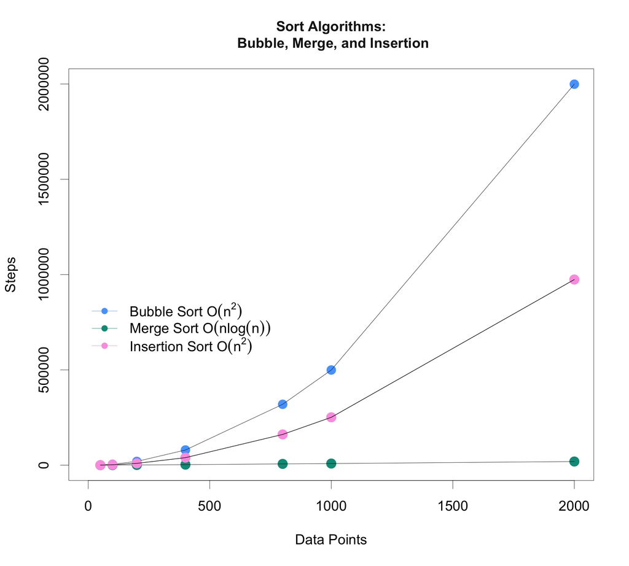